# Temperature analysis

Ariana S Huffmyer

11/30/2021

Temperature analysis for Alexander et al., “Larval thermal conditioning does not improve post-settlement thermal tolerance in the dominant reef-building coral, *Montipora capitata*”.

# Set Up

Examine and plot temperature treatments during the larval conditioning, settlement, and spat survival phases of the experiment.

# Larval temperature treatments

Load temperature files for temperature logging in the ambient and cold sumps (headers) during larval rearing and calibrate to calibration file.

```r
#Load calibration data, extract intercept and slope to calibrate individual loggers
calib.data.T <- read.csv("Temperature/Temp_Logger_Calibration.csv", header=TRUE) #load data with a header, separated by commas, with NA as NA
calib.T <- as.data.frame(t(apply(calib.data.T[2:21], 2, function(y)(coef(lm(y ~ calib.data.T$SN_10779069)))))) #apply linear model to obtain calibration equations for specific logger
colnames(calib.T) <- c("Intercept",  "Slope") #rename columns

#Load data
AmbSump<-read.csv("Temperature/Ambient_Sump_10779069.csv",header=TRUE, sep=",", na.strings="NA") #this logger is the standard, no change
#Intercept: -2.757311e-14     slope= 1.0000000, line equation y=1  x +-2.757311e-14
AmbSump$calibratedT<-(AmbSump$Temp*1)+-2.757311e-14 #apply calibration from linear model for specific logger
names(AmbSump)[3] <- "AmbientSump" #rename calibrated col to tank name
AmbSump<- AmbSump[ -c(2) ] #drop uncalibrated col

ColdSump<-read.csv("Temperature/cold_sump_10487935.csv",header=TRUE, sep=",", na.strings="NA") #read in cold tempreature logger
#Intercept: -5.645523e-02   Slope: 1.0004740, line equation y=1.0004740x + -5.645523e-02
ColdSump$calibratedT<-(ColdSump$Temp*1.0004740)+-5.645523e-02 #apply linear calibration
names(ColdSump)[3] <- "ColdSump" #rename calibrated col to tank name
ColdSump<- ColdSump[ -c(2) ] #drop uncalibrated col
```

Plot ambient and cold sumps for reference for header source for conicals. Note that temperature data presented in manuscript and analyzed below for manuscript plots was obtained from individual temperature loggers in conical vessels.

```r
#combine Amb and cold sump for plotting
SUMPdf<-merge(AmbSump,ColdSump, by="Date.Time") #merge and keep only time points over lap
SUMPdf<-melt(SUMPdf,id=c("Date.Time")) #change from wide to long format
SUMPdf$Date.Time<-as.character(SUMPdf$Date.Time) #change date time to character
SUMPdf$Date <- format(as.POSIXct(strptime(SUMPdf$Date.Time,"%m/%d/%Y %H:%M",tz="")) ,format = "%m/%d") #change date time to date only format

SUMP_mean <- plyr::ddply(SUMPdf, c("variable", "Date"), summarise,
                          N    = length(value[!is.na(value)]), #calculate the length of the data frame, excluding NA’s
                          mean = mean(value, na.rm=TRUE), #calculate mean of response variable (temperature), removing NA's
                          sd   = sd(value, na.rm=TRUE), #calculate standard deviation of temperature
                          se   = sd / sqrt(N), #calculate standard error of temperature
                          max = max(value, na.rm=TRUE) #calculate max temperature, could also calculate min () if desired
)
SUMP_mean #display summary
```

```
##      variable  Date  N     mean         sd         se      max
## 1 AmbientSump 07/08 36 27.77408 0.07786155 0.01297693 27.94900
## 2 AmbientSump 07/09 96 27.43822 0.45552152 0.04649147 28.12200
## 3 AmbientSump 07/10 44 26.10527 0.60885303 0.09178805 26.42600
## 4    ColdSump 07/08 36 25.05239 0.18019136 0.03003189 25.45663
## 5    ColdSump 07/09 96 25.02515 0.14797802 0.01510294 25.50566
## 6    ColdSump 07/10 44 24.51421 0.60594146 0.09134911 24.89937
```

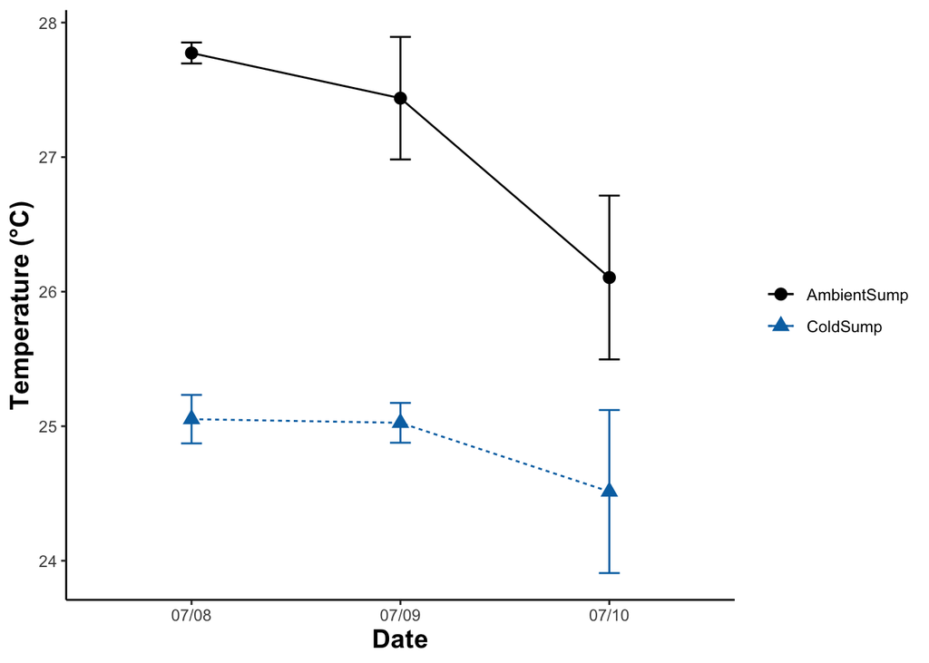

```r
SUMP_plot<-ggplot(data=SUMP_mean, aes(x=Date, y=mean, group = variable, color=variable)) + #plot temperature in sumps
  geom_errorbar(aes(ymin=mean-sd, ymax=mean+sd),
                width=0.1)+
  geom_point(aes(shape=variable), size=3)+ #plot points
  geom_line(aes(color=variable, linetype=variable))+ #plot lines between points
  scale_color_manual(values=c("#000000","#0072B2"))+ #set colors
  ylab("Temperature (°C)") +
  xlab("Date") + #Label the X Axis
  theme_bw() + #Set the background color
  theme(axis.line = element_line(color = 'black'), #Set the axes color
        axis.title=element_text(size=14,face="bold"), #Set axis format
        panel.border = element_blank(), #Set the border
        panel.grid.major = element_blank(), #Set the major gridlines
        panel.grid.minor = element_blank(), #Set the minor gridlines
        plot.background =element_blank(), #Set the plot background
        legend.title = element_blank(),
        legend.key = element_blank()) #Set plot legend key

SUMP_plot
```

Cold and ambient temperature sumps (header tanks) had distinct temperature regimes.

Next, plot temperature data obtained from loggers in conicals and view averages of each treatment (Script and data from Hancock et al. 2021, reproduced with authors’ permission). This data represents conditions that larvae were directly exposed to during experiment.

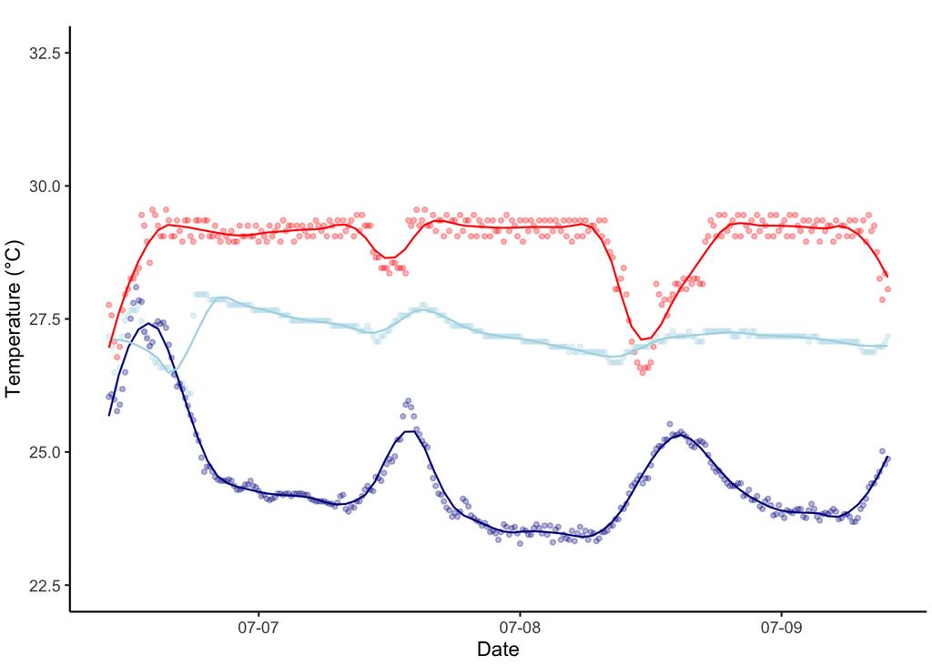

```r
hot<-read_excel("Temperature/conicals.xlsx",sheet="Hot") #load data files
ambient<-read_excel("Temperature/conicals.xlsx",sheet="Ambient")
cold<-read_excel("Temperature/conicals.xlsx",sheet="Cold")

data<-full_join(full_join(hot,ambient,by="Date"),cold,by="Date")%>% #join data files together from each treatment and format
     dplyr::rename(Hot=Temp.x,Ambient=Temp.y)%>%
     gather(Treatment,Temp,-Date)%>%
     filter(Date>as.POSIXct("2019-07-06")&Date<as.POSIXct("2019-07-9")) #isolate days of experiment
data$Treatment <- factor(data$Treatment,levels = c("Cold", "Ambient", "Hot")) #re order factors

conical_plot<-ggplot(data)+geom_point(aes(Date,Temp,color=Treatment),alpha=0.3,size=1)+ #Plot temprature treatments
     theme_classic()+
     scale_color_manual(values=c("darkblue","lightblue","red"), labels=c("Cool", "Ambient", "Warm"))+
     geom_smooth(aes(Date,Temp,color=Treatment),se=FALSE,span=0.15,size=0.5)+
     scale_x_datetime(date_breaks="1 day",minor_breaks=waiver(),labels=date_format("%m-%d"))+
     ylim(22.5, 32.5)+
     ylab("Temperature (°C)")+
     theme(legend.key.size = unit(1,"line"))+
    theme(legend.position="none")+
    theme(legend.title=element_text(size=10))+
    theme(plot.margin = margin(0.5, 0.1, 0.1, 0.1, "cm"))+
    theme(legend.text=element_text(size=9)); conical_plot
```

```r
#grab summary of temperature treatments
data%>%group_by(Treatment)%>%summarise(mean=mean(Temp),sd=sd(Temp),se=std.error(Temp))
```

```
## # A tibble: 3 × 4
##   Treatment  mean    sd     se
##   <fct>     <dbl> <dbl>  <dbl>
## 1 Cold       24.5 1.00  0.0592
## 2 Ambient    27.2 0.347 0.0205
## 3 Hot        28.9 0.626 0.0369
```

```r
#create a legend for later
#build a plot for the legend
legend_plot<-conical_plot +
  theme(legend.position="right")

# extract the legend from one of the plots
legend <- get_legend(
  # create some space to the left of the legend
  legend_plot)
```

# Temperatures during larval settlement and spat survival

Display temperatures in tanks during larval settlement and spat survival phases of the experiment. During larval settlement, larvae were kept at ambient temperature. During spat survival, spat were then exposed to either ambient or high temperature treatments.

```r
#read in data from the 4 tanks used for larval settlement and spat survival
Tank1<-read.csv("Temperature/Tank1_5Sept_10779060.csv",header=TRUE, sep=",", na.strings="NA")
#Intercept: -5.899138e-02     Slope: 1.0015297 , line equation y=1.0015297 x + -5.899138e-02
Tank1$calibratedT<-(Tank1$Temp*1.0015297)+-5.899138e-02
names(Tank1)[4] <- "Tank1" #rename calibrated col to tank name
Tank1<- Tank1[ -c(2) ] #drop uncalibrated col

Tank2<-read.csv("Temperature/Tank2_5Sept_10779068.csv",header=TRUE, sep=",", na.strings="NA")
#Intercept: 6.285066e-02  Slope: 0.9975927   , line equation y=0.9975927   x + 6.285066e-02
Tank2$calibratedT<-(Tank2$Temp*1.0015297)+6.285066e-02
names(Tank2)[4] <- "Tank2" #rename calibrated col to tank name
Tank2<- Tank2[ -c(2) ] #drop uncalibrated col

Tank3<-read.csv("Temperature/Tank3_5Sept_10487935.csv",header=TRUE, sep=",", na.strings="NA")
#Intercept: -5.645523e-02  Slope: 1.0004740   , line equation y=1.0004740   x +-5.645523e-02
Tank3$calibratedT<-(Tank3$Temp*1.0004740)+-5.645523e-02
names(Tank3)[4] <- "Tank3" #rename calibrated col to tank name
Tank3<- Tank3[ -c(2) ] #drop uncalibrated col

Tank4<-read.csv("Temperature/Tank4_5Sept_10779069.csv",header=TRUE, sep=",", na.strings="NA")
#Intercept: -2.757311e-14     slope= 1.0000000, line equation y=1  x +-2.757311e-14
Tank4$calibratedT<-(Tank4$Temp*1)+-2.757311e-14
names(Tank4)[4] <- "Tank4" #rename calibrated col to tank name
Tank4<- Tank4[ -c(2) ] #drop uncalibrated col

#Join dataframes together
Tankdf<-right_join(Tank1, Tank2, by=c("DateTime", "Phase"))
Tankdf<-right_join(Tankdf, Tank3, by=c("DateTime", "Phase"))
Tankdf<-right_join(Tankdf, Tank4, by=c("DateTime", "Phase"))

Tankdf$DateTime<-as.character(as.POSIXct(Tankdf$DateTime, format="%m/%d/%y %H:%M"))
```

Separate settlement and survival phases and assign temperature treatment names for the settlement (ambient only) and spat survival phases (high and ambient).

```r
settlement_temps<-Tankdf%>%
  filter(Phase=="Settlement")%>%
  gather(Tank, Temp, Tank1:Tank4) #gather data set

settlement_temps$Treatment<-"Ambient" #set treatment for settlement

survival_temps<-Tankdf%>%
  filter(Phase=="Survival")%>%
  gather(Tank, Temp, Tank1:Tank4)%>%
  mutate(Treatment = case_when(Tank=="Tank1" ~ "High",
                               Tank=="Tank2" ~ "Ambient",
                               Tank=="Tank3" ~ "Ambient",
                               Tank=="Tank4" ~ "High"))
```

## Larval settlement

Plot temperatures during larval settlement and calculate mean values.

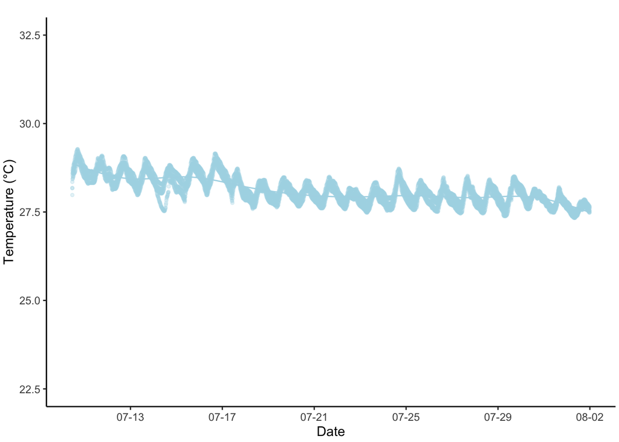

```r
settlement_plot<-ggplot(settlement_temps)+geom_point(aes(as.POSIXct(DateTime),Temp,color=Treatment),alpha=0.3,size=1)+
     theme_classic()+
     scale_color_manual(values=c("lightblue"))+
     geom_smooth(aes(as.POSIXct(DateTime),Temp,color=Treatment),se=FALSE,span=0.15,size=0.5)+
     scale_x_datetime(date_breaks="4 days",minor_breaks=waiver(),labels=date_format("%m-%d"))+
     ylim(22.5, 32.5)+
     xlab("Date")+
     ylab("Temperature (°C)")+
     theme(legend.key.size = unit(0.5,"line"))+
    theme(plot.margin = margin(0.5, 0.1, 0.1, 0.1, "cm"))+
    theme(legend.position="none"); settlement_plot
```

```r
#grab summary of the data
settlement_temps%>%group_by(Treatment)%>%summarise(mean=mean(Temp), sd=sd(Temp), se=std.error(Temp))
```

```
## # A tibble: 1 × 4
##   Treatment  mean    sd      se
##   <chr>     <dbl> <dbl>   <dbl>
## 1 Ambient    28.1 0.378 0.00406
```

## Spat survival

Plot temperatures during spat survival and calculate mean values.

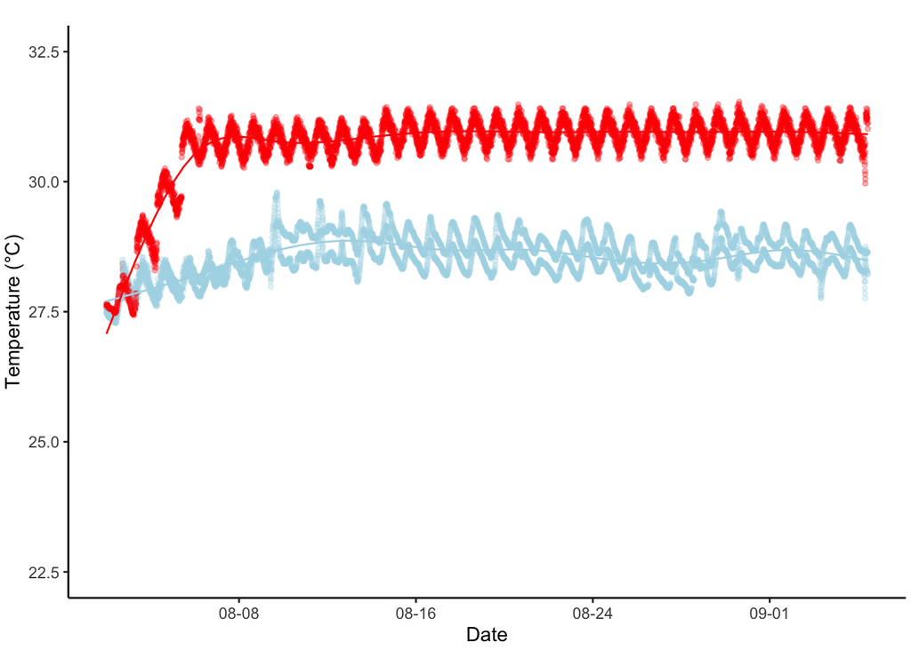

```r
recruit_plot<-ggplot(survival_temps)+geom_point(aes(as.POSIXct(DateTime),Temp,color=Treatment),alpha=0.3,size=1)+
     theme_classic()+
     scale_color_manual(values=c("lightblue", "red"))+
     geom_smooth(aes(as.POSIXct(DateTime),Temp,color=Treatment),se=FALSE,span=0.15,size=0.5)+
     scale_x_datetime(date_breaks="8 days",minor_breaks=waiver(),labels=date_format("%m-%d"))+
     #scale_y_continuous(breaks=seq(23,32,1))+
     ylim(22.5, 32.5)+
     xlab("Date")+
     ylab("Temperature (°C)")+
     theme(legend.key.size = unit(0.5,"line"))+
    theme(plot.margin = margin(0.5, 0.1, 0.1, 0.1, "cm"))+
    theme(legend.position="none"); recruit_plot
```

```r
#grab summary of the data
survival_temps%>%group_by(Treatment)%>%summarise(mean=mean(Temp), sd=sd(Temp), se=std.error(Temp))
```

```
## # A tibble: 2 × 4
##   Treatment  mean    sd      se
##   <chr>     <dbl> <dbl>   <dbl>
## 1 Ambient    28.5 0.391 0.00481
## 2 High       30.7 0.749 0.00921
```

# Generate temperature figure

Plot temperature for all phases of the experiment.

```r
temp_panel<-plot_grid(conical_plot, settlement_plot, recruit_plot, labels = c("a. Larval Exposure", "b. Larval Settlement", "c. Spat Survival"), ncol=3, nrow=1, rel_heights= c(1,1,1), rel_widths = c(1,1,1), label_size = 10, label_y=1, align="vh")

# add the legend to the row we made earlier. Give it one-third of
# the width of one plot (via rel_widths).
temp_plot_legend<-plot_grid(temp_panel, legend, rel_widths = c(6, .6), ncol=2, nrow=1)

ggsave(filename="Figures/Full_Temp_Figure.png", plot=temp_plot_legend, dpi=500, width=12, height=2, units="in")

#temp_plot_legend
```